# Statistical Inference Project: part 2

**Instruction**: Now in the second portion of the class, we’re going to analyze the ToothGrowth data in the R datasets package.

1. Load the ToothGrowth data and perform some basic exploratory data analyses

```r
data(ToothGrowth);
str(ToothGrowth);
```

```
## 'data.frame':    60 obs. of  3 variables:
##  $ len : num  4.2 11.5 7.3 5.8 6.4 10 11.2 11.2 5.2 7 ...
##  $ supp: Factor w/ 2 levels "OJ","VC": 2 2 2 2 2 2 2 2 2 2 ...
##  $ dose: num  0.5 0.5 0.5 0.5 0.5 0.5 0.5 0.5 0.5 0.5 ...
```

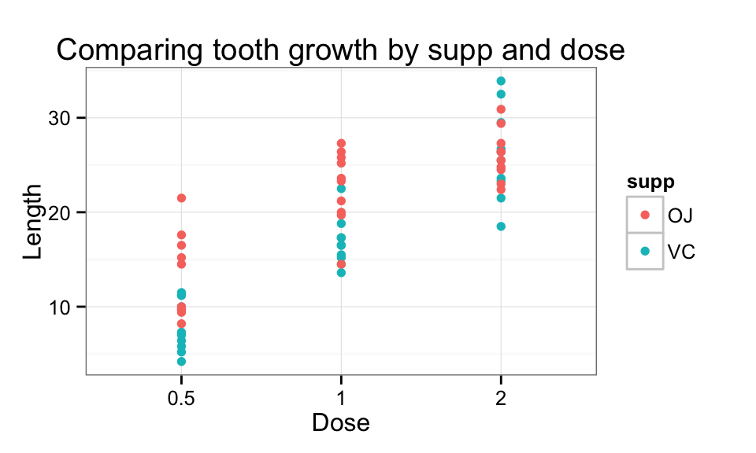

```r
library(ggplot2)
ggplot(data=ToothGrowth, aes(x=factor(dose), y=len, color=supp))  +
    geom_point()+
    xlab("Dose")+
    ylab("Length")+
    theme_bw()+
    ggtitle("Comparing tooth growth by supp and dose")
```

2. Provide a basic summary of the data. *Summary:*
- The data has 60 records and three variables(len, supp, dose).
- There are three doses (0.5, 1, 2) under the dose varialble and 2 factors (“VC”, “OJ”) under the supp variable.
- The len variable has the tooth growth data, which can be divided into to six group according to the variables dose and supp.
- Below is a table reshaped to show the mean and standard deviation of each group.

```r
ToothGrowth$ID <-rep(1:10,6);library(reshape2);
dat <- dcast(ToothGrowth, dose+supp~ID, value.var="len");

names(dat)[-(1:2)]<-paste("len_",names(dat[-(1:2)]), sep="");
dat$mean<-sapply(1:6, function(x) {mean(as.numeric(dat[x,3:12]))});
dat$sd<-sapply(1:6, function(x) {sd(as.numeric(dat[x,3:12]))});
dat$Group<-1:6
library(xtable);
print(xtable(dat[-(3:12)]),type='html')
```

|  | dose | supp | mean | sd | Group |
| --- | --- | --- | --- | --- | --- |
| 1 | 0.50 | OJ | 13.23 | 4.46 | 1 |
| 2 | 0.50 | VC | 7.98 | 2.75 | 2 |
| 3 | 1.00 | OJ | 22.70 | 3.91 | 3 |
| 4 | 1.00 | VC | 16.77 | 2.52 | 4 |
| 5 | 2.00 | OJ | 26.06 | 2.66 | 5 |
| 6 | 2.00 | VC | 26.14 | 4.80 | 6 |

3. Use confidence intervals and hypothesis tests to compare tooth growth by supp and dose. (Use the techniques from class even if there’s other approaches worth considering)
- calculate the 95% confidence interval between the two groups as stated in the table below. we use unpaired t-test assuming the groups are independent.
- We first tried unequal variance t-test. we also tried t.test assuming equal variance. Both equal or unequal variances reach a same conclusion.

```r
conFun <- function(m=1, n=2, df=dat) {
    temp<-t.test(df[m,3:12],df[n,3:12],paired=F, var.equal=F)$conf[1:2];
    return(data.frame(Data_1=paste("group_",m,": dose=",df[m,1],", supp=",df[m,2],sep=""),
    Data_2=paste("group_",n,": dose=",df[n,1],", supp=",df[n,2],sep=""),Lowlimit=temp[1],Uplimit=temp[2]))
    }

print(xtable(rbind(conFun(1,2),conFun(3,4),conFun(5,6))),type='html')
```

|  | Data_1 | Data_2 | Lowlimit | Uplimit |
| --- | --- | --- | --- | --- |
| 1 | group_1: dose=0.5, supp=OJ | group_2: dose=0.5, supp=VC | 1.72 | 8.78 |
| 2 | group_3: dose=1, supp=OJ | group_4: dose=1, supp=VC | 2.80 | 9.06 |
| 3 | group_5: dose=2, supp=OJ | group_6: dose=2, supp=VC | -3.80 | 3.64 |

```r
print(xtable(rbind(conFun(1,3),conFun(3,5),conFun(2,4),conFun(4,6))),type='html')
```

|  | Data_1 | Data_2 | Lowlimit | Uplimit |
| --- | --- | --- | --- | --- |
| 1 | group_1: dose=0.5, supp=OJ | group_3: dose=1, supp=OJ | -13.42 | -5.52 |
| 2 | group_3: dose=1, supp=OJ | group_5: dose=2, supp=OJ | -6.53 | -0.19 |
| 3 | group_2: dose=0.5, supp=VC | group_4: dose=1, supp=VC | -11.27 | -6.31 |
| 4 | group_4: dose=1, supp=VC | group_6: dose=2, supp=VC | -13.05 | -5.69 |

4. State your conclusions and the assumptions needed for your conclusions.
- The 95% confidence intervals (or CI) between “OJ” and “VC” for dose =0.5 and 1 is above zero, however the 95% CI between “OJ” and “VC” for the dose of 2 includes zero.
- We have 95% confidence that “OJ”" has more effect on the tooth growth that “VC” at lower dose (0.5 and 1).
- “OJ” and “VC” have similar effect on tooth growth at a higher dose of 2.